# String Distance Comparisons

Jolene Lim

# 1. Setup

Load required libraries

Load datasets

Extract only unique combinations of EDs and addresses

# 2. Cleaning Addresses

Importing functions created by Kyi, `rem_dup_word()` and `str_clean()`. Note: `str_clean()` is modified such that the output is a cleaned `x` rather than `x$cleaned`. This allows `x` to be a vector rather than strictly a dataframe.

Applying the functions onto `unique_addresses`

# 3. Matching Addresses with EDict

The goal here is to create a “dictionary of matches”, `match_dict`, which contains the variables:  
* ED  
* raw: raw address from sample  
* match_{method}: cleaned address that exists in the street dictionary (`edict`)  
* dscore_{method}: dscore between match and cleaned address  
where {method} is one of the string match methods explained below.

The purpose of `match_dict` is so that when matching between a raw address and cleaned Edict address needs to be done for the entire sample, one can just look up the `raw` address in `match_dict` and take the `matched` address as the cleaned, matching address.

### Note: String Match Algorithms

To do so, it is first necessary to match records from the `edict` to raw and decide which match (based on different string distance algorithms) is the most accurate. A intermediate dataframe, `add_matches`, will be created for this purpose.

All string algorithms provided by `stringdist_join()` function will be tested, with the exception of: * Hamming: It requires both strings to be of equal distance, which is unlikely the case for accurate matches in our context.  
* LCS (Longest Common Substring): It calculates the minimum number of symbols that have to be removed in both strings until resulting substrings are identical. In our case transposition is the likelier error compared to additional characters introduced by typos, hence this is not very useful.  
* Soundex: This is a binary match system which may be too strict for our purposes. * Levenshtein distance (lv) and Optimal String Alignment (OSA): these are similar to the Damerau-Levenshtein distance (dl) but stricter, hence only dl is chosen.

| ED | raw | clean | match_dl | dscore_dl | match_qgram | dscore_qgram | match_cos | dscore_cos | match_jac | dscore_jac | match_jw | dscore_jw |
| --- | --- | --- | --- | --- | --- | --- | --- | --- | --- | --- | --- | --- |
| 0001 | ?? STREET | ?? | VINE | 4 | NA | NA | COLUMBIA HEIGHTS | 1.0000000 | COLUMBIA HEIGHTS | 1.0000000 | COLUMBIA HEIGHTS | 1.0000000 |
| 0001 | BECKA ST | BECKA | HICKS | 3 | NA | NA | ELIZABETH PLACE | 0.3739010 | MCKENNEY | 0.6250000 | HICKS | 0.4000000 |
| 0001 | CLEGS OLD ST | CLEGS OLD | NA | NA | NA | NA | OLD FULTON | 0.3571757 | COLUMBIA HEIGHTS | 0.5333333 | EAST RIVER | 0.4555556 |
| 0001 | COLUMBIA HOTEL | COLUMBIA | NA | NA | NA | NA | COLUMBIA HEIGHTS | 0.2884875 | COLUMBIA HEIGHTS | 0.4285714 | COLUMBIA HEIGHTS | 0.1666667 |
| 0001 | COLUMBIA HTS | COLUMBIA HEIGHTS | COLUMBIA HEIGHTS | 0 | COLUMBIA HEIGHTS | 0 | COLUMBIA HEIGHTS | 0.0000000 | COLUMBIA HEIGHTS | 0.0000000 | COLUMBIA HEIGHTS | 0.0000000 |
| 0001 | DOUGHERTY ST | DOUGHERTY | DOUGHTY | 2 | DOUGHTY | 2 | DOUGHTY | 0.1180829 | DOUGHTY | 0.2222222 | DOUGHTY | 0.0740741 |

# 4. EDA of Results

## How consistent are the matches?

Ideally, all 5 algorithm matches will perfectly match the clean string. This table explores the number of records by the number of perfect matches with (which ranges from 0-5), e.g. 0 would mean that none of the algorithms produced a perfect match with the cleaned string.

| No. of Perfect Matches | No. of Records | % |
| --- | --- | --- |
| 0 | 195 | 23.9 |
| 4 | 5 | 0.6 |
| 5 | 615 | 75.5 |

615 (75.5%) records have a perfect match.

| No. of Unique Matches Given by Algorithms | No. of Records | % |
| --- | --- | --- |
| 1 | 725 | 89.0 |
| 2 | 50 | 6.1 |
| 3 | 27 | 3.3 |
| 4 | 13 | 1.6 |

We know that 615 records have perfect matches between all results from the string algorithms and the clean string. Additionally, 725 - 615 = 110 (13.5%) records have all string algorithms giving the same result–suggesting that this is a problem with the cleaning rather than matching. To verify this, the records that are not a perfect match, but have all the same results are shown below:

| ED | raw | clean | match_dl | dscore_dl | match_qgram | dscore_qgram | match_cos | dscore_cos | match_jac | dscore_jac | match_jw | dscore_jw |
| --- | --- | --- | --- | --- | --- | --- | --- | --- | --- | --- | --- | --- |
| 0001 | DOUGHERTY ST | DOUGHERTY | DOUGHTY | 2 | DOUGHTY | 2 | DOUGHTY | 0.1180829 | DOUGHTY | 0.2222222 | DOUGHTY | 0.0740741 |
| 0001 | HECKS ST | HECKS | HICKS | 1 | HICKS | 2 | HICKS | 0.2000000 | HICKS | 0.3333333 | HICKS | 0.1333333 |
| 0001 | HICK ST | HICK | HICKS | 1 | HICKS | 1 | HICKS | 0.1055728 | HICKS | 0.2000000 | HICKS | 0.0666667 |
| 0001 | MIDDAUGH ST | MIDDAUGH | MIDDAGH | 1 | MIDDAGH | 1 | MIDDAGH | 0.0513167 | MIDDAGH | 0.1428571 | MIDDAGH | 0.0416667 |
| 0001 | MIDDOGH ST | MIDDOGH | MIDDAGH | 1 | MIDDAGH | 2 | MIDDAGH | 0.1111111 | MIDDAGH | 0.2857143 | MIDDAGH | 0.0952381 |
| 0001 | ORELLOW ST | ORELLOW | WILLOW | 3 | WILLOW | 5 | WILLOW | 0.2372299 | WILLOW | 0.5000000 | WILLOW | 0.2539683 |
| 0001 | POLAR ST | POLAR | POPLAR | 1 | POPLAR | 1 | POPLAR | 0.0513167 | POPLAR | 0.0000000 | POPLAR | 0.0555556 |
| 0001 | TALTON STREET | TALTON | FULTON | 2 | FULTON | 4 | FULTON | 0.2783122 | FULTON | 0.4285714 | FULTON | 0.2222222 |
| 0001 | TULTON ST | TULTON | FULTON | 1 | FULTON | 2 | FULTON | 0.1339746 | FULTON | 0.1666667 | FULTON | 0.1111111 |
| 0001 | WELLOW ST | WELLOW | WILLOW | 1 | WILLOW | 2 | WILLOW | 0.1000000 | WILLOW | 0.4000000 | WILLOW | 0.1111111 |
| 0002 | CRAM BERRY ST | CRAM BERRY | CRANBERRY | 2 | CRANBERRY | 3 | CRANBERRY | 0.0963039 | CRANBERRY | 0.3333333 | CRANBERRY | 0.1037037 |
| 0002 | CRAMBERRY ST | CRAMBERRY | CRANBERRY | 1 | CRANBERRY | 2 | CRANBERRY | 0.0666667 | CRANBERRY | 0.2500000 | CRANBERRY | 0.0740741 |
| 0002 | CRAMBERRY STREET | CRAMBERRY | CRANBERRY | 1 | CRANBERRY | 2 | CRANBERRY | 0.0666667 | CRANBERRY | 0.2500000 | CRANBERRY | 0.0740741 |
| 0002 | INSKID | INSKID | HICKS | 5 | HICKS | 5 | HICKS | 0.3675445 | HICKS | 0.5714286 | HICKS | 0.4111111 |
| 0002 | WILLIAM ST | WILLIAM | WILLOW | 3 | WILLOW | 5 | WILLOW | 0.2372299 | WILLOW | 0.5000000 | WILLOW | 0.2539683 |
| 0003 | CANBERRY | CANBERRY | CRANBERRY | 1 | CRANBERRY | 1 | CRANBERRY | 0.0202041 | CRANBERRY | 0.0000000 | CRANBERRY | 0.0370370 |
| 0003 | MANGE STREET | MANGE | ORANGE | 2 | ORANGE | 3 | ORANGE | 0.2697033 | ORANGE | 0.4285714 | ORANGE | 0.1777778 |
| 0003 | WILLIOW STREET | WILLIOW | WILLOW | 1 | WILLOW | 1 | WILLOW | 0.0352362 | WILLOW | 0.0000000 | WILLOW | 0.0476190 |
| 0004 | CLERK ST | CLERK | CLARK | 1 | CLARK | 2 | CLARK | 0.2000000 | CLARK | 0.3333333 | CLARK | 0.1333333 |
| 0004 | CLERK STREET | CLERK | CLARK | 1 | CLARK | 2 | CLARK | 0.2000000 | CLARK | 0.3333333 | CLARK | 0.1333333 |
| 0004 | COLLAGE PLACE | COLLAGE PLACE | COLLEGE PLACE | 1 | COLLEGE PLACE | 2 | COLLEGE PLACE | 0.0377496 | COLLEGE PLACE | 0.0000000 | COLLEGE PLACE | 0.0790598 |
| 0004 | COLUMBIA HIGHTS | COLUMBIA HIGHTS | COLUMBIA HEIGHTS | 1 | COLUMBIA HEIGHTS | 1 | COLUMBIA HEIGHTS | 0.0253206 | COLUMBIA HEIGHTS | 0.0714286 | COLUMBIA HEIGHTS | 0.0208333 |
| 0004 | FAIRMAN ST | FAIRMAN | FURMAN | 2 | FURMAN | 3 | FURMAN | 0.1835034 | FURMAN | 0.2857143 | FURMAN | 0.1507937 |
| 0004 | HICKE STREET | HICKE | HICKS | 1 | HICKS | 2 | HICKS | 0.2000000 | HICKS | 0.3333333 | HICKS | 0.1333333 |
| 0004 | PIENEPORT STREET | PIENEPORT | PIERREPONT | 3 | PIERREPONT | 1 | PIERREPONT | 0.0292747 | PIERREPONT | 0.0000000 | PIERREPONT | 0.1870370 |
| 0005 | AULTON STREET | AULTON | FULTON | 1 | FULTON | 2 | FULTON | 0.1666667 | FULTON | 0.2857143 | FULTON | 0.1111111 |
| 0005 | CLERK ST | CLERK | CLARK | 1 | CLARK | 2 | CLARK | 0.2000000 | CLARK | 0.3333333 | CLARK | 0.1333333 |
| 0005 | FUTON ST | FUTON | FULTON | 1 | FULTON | 1 | FULTON | 0.0871291 | FULTON | 0.1666667 | FULTON | 0.0555556 |
| 0005 | MONSOR PLACE | MONSOR PLACE | MONROE PLACE | 2 | MONROE PLACE | 2 | MONROE PLACE | 0.0645857 | MONROE PLACE | 0.0909091 | MONROE PLACE | 0.0858586 |
| 0005 | PIERRPONT STREET | PIERRPONT | PIERREPONT | 1 | PIERREPONT | 1 | PIERREPONT | 0.0292747 | PIERREPONT | 0.0000000 | PIERREPONT | 0.0333333 |

[output cut: 80 more lines]

It does seem that for such records, we can confidently replace the string with the matched string. At this point, perfect matches and records with identical matches comprise 89% of the records, i.e. we can confidently say at least 89% of our records are accurately matched.

Another 90 (11.0%) records have different matches depending on string algorithm. These are shown below.

| ED | raw | clean | match_dl | dscore_dl | match_qgram | dscore_qgram | match_cos | dscore_cos | match_jac | dscore_jac | match_jw | dscore_jw |
| --- | --- | --- | --- | --- | --- | --- | --- | --- | --- | --- | --- | --- |
| 0001 | ?? STREET | ?? | VINE | 4 | 0 | 0 | COLUMBIA HEIGHTS | 1.0000000 | COLUMBIA HEIGHTS | 1.0000000 | COLUMBIA HEIGHTS | 1.0000000 |
| 0001 | BECKA ST | BECKA | HICKS | 3 | 0 | 0 | ELIZABETH PLACE | 0.3739010 | MCKENNEY | 0.6250000 | HICKS | 0.4000000 |
| 0001 | CLEGS OLD ST | CLEGS OLD | 0 | 0 | 0 | 0 | OLD FULTON | 0.3571757 | COLUMBIA HEIGHTS | 0.5333333 | EAST RIVER | 0.4555556 |
| 0001 | COLUMBIA HOTEL | COLUMBIA | 0 | 0 | 0 | 0 | COLUMBIA HEIGHTS | 0.2884875 | COLUMBIA HEIGHTS | 0.4285714 | COLUMBIA HEIGHTS | 0.1666667 |
| 0001 | ELIZABETH ST | ELIZABETH | 0 | 0 | 0 | 0 | ELIZABETH PLACE | 0.0954660 | ELIZABETH PLACE | 0.2727273 | ELIZABETH PLACE | 0.1333333 |
| 0001 | FAIRACRE ST | FAIRACRE | 0 | 0 | 0 | 0 | EAST RIVER | 0.3056349 | EAST RIVER | 0.6000000 | POPLAR PLACE | 0.3194444 |
| 0001 | HICKS ST 19 | HICKS ST NINETEENTH | 0 | 0 | 0 | 0 | COLUMBIA HEIGHTS | 0.3666667 | HICKS | 0.4444444 | HICKS | 0.2456140 |
| 0001 | HOLGER LITTES | HOLGER LITTES | 0 | 0 | 0 | 0 | COLUMBIA HEIGHTS | 0.2818152 | COLUMBIA HEIGHTS | 0.4000000 | EVERITT | 0.3003663 |
| 0001 | MCHENNING ST | MCHENNING | MCKENNEY | 4 | 0 | 0 | MCKENNY | 0.2254033 | MCKENNEY | 0.5555556 | MCKENNY | 0.2433862 |
| 0001 | MCKENNA ST | MCKENNA | MCKENNY | 1 | MCKENNY | 2 | MCKENNY | 0.1111111 | MCKENNEY | 0.2857143 | MCKENNY | 0.0952381 |
| 0001 | MCKENNA STREET | MCKENNA | MCKENNY | 1 | MCKENNY | 2 | MCKENNY | 0.1111111 | MCKENNEY | 0.2857143 | MCKENNY | 0.0952381 |
| 0001 | NEW ASSEMBLY DISTRICT 2 | NEW ASSEMBLY DISTRICT 2 | 0 | 0 | 0 | 0 | EAST RIVER | 0.2904337 | COLUMBIA HEIGHTS | 0.5000000 | EVERITT | 0.4182195 |
| 0001 | PROFECTON ROAD | PROFECTON ROAD | 0 | 0 | 0 | 0 | POPLAR | 0.3969773 | POPLAR PLACE | 0.4166667 | FULTON | 0.4742063 |
| 0002 | NEW AD 2 | NEW AD 2 | 0 | 0 | 0 | 0 | CADMAN PLAZA WEST | 0.3184458 | CADMAN PLAZA WEST | 0.5714286 | CADMAN PLAZA WEST | 0.4936275 |
| 0003 | COL HETS | COL HETS | 0 | 0 | 0 | 0 | COLUMBIA HEIGHTS | 0.2884875 | COLUMBIA HEIGHTS | 0.4285714 | COLUMBIA HEIGHTS | 0.2916667 |
| 0003 | CRANBERRY STRET | CRANBERRY STRET | 0 | 0 | 0 | 0 | CRANBERRY | 0.1188961 | CRANBERRY | 0.3000000 | CRANBERRY | 0.1333333 |
| 0004 | S HENRY ST & CLAERN AT ROAD | SOUTH HENRY ST CLAERN AT ROAD | 0 | 0 | 0 | 0 | FORT STERLING PARK | 0.2290182 | COLUMBIA HEIGHTS | 0.4444444 | HENRY | 0.2795699 |
| 0007 | GRACE COUNT ALLEY | GRACE COUNT ALLEY | GRACE COURT ALLEY | 1 | GRACE COURT ALLEY | 2 | GRACE COURT ALLEY | 0.0350987 | GRACE COURT ALLEY | 0.0833333 | GRACE COURT ALLEY | 0.0392157 |
| 0007 | GRACE COURT ALLEYS | GRACE COURT ALLEYS | GRACE COURT ALLEY | 1 | GRACE COURT ALLEY | 1 | GRACE COURT ALLEY | 0.0168079 | GRACE COURT ALLEY | 0.0833333 | GRACE COURT ALLEY | 0.0185185 |
| 0008 | FORAK MON ST | FORAK MON | JORALEMON | 3 | FURMAN | 5 | JORALEMON | 0.2727273 | FURMAN | 0.4444444 | JORALEMON | 0.2222222 |
| 0011 | GARDEN PL HENRY STREET | GARDEN PLACE HENRY | 0 | 0 | 0 | 0 | GARDEN PLACE | 0.0719223 | GARDEN PLACE | 0.1666667 | GARDEN PLACE | 0.1111111 |
| 0012 | FIONE RENT STR | FIONE RENT | 0 | 0 | 0 | 0 | PIERREPONT | 0.2650316 | PIERREPONT | 0.3333333 | PIERREPONT | 0.2666667 |
| 0012 | PERROTT PREMPONT STREET | PERROTT PREMPONT | 0 | 0 | 0 | 0 | PIERREPONT | 0.1077822 | PIERREPONT | 0.3333333 | PIERREPONT | 0.2717593 |
| 0013 | SCHOMERDOSA ST | SCHOMERDOSA | SCHERMERHORN | 5 | 0 | 0 | SCHERMERHORN | 0.2843736 | SCHERMERHORN | 0.3000000 | SCHERMERHORN | 0.3315296 |
| 0014 | #143 COURT ST | #143 COURT | COURT | 5 | COURT | 5 | COURT | 0.2928932 | COURT | 0.5000000 | BOERUM PLACE | 0.5277778 |
| 0014 | CADYER ST | CADYER | BERGEN | 5 | DEAN | 4 | DEAN | 0.3876276 | DEAN | 0.5714286 | COURT | 0.4222222 |
| 0014 | CHOUPIC ST | CHOUPIC | COURT | 4 | 0 | 0 | PACIFIC | 0.2964735 | COURT | 0.6250000 | COURT | 0.3238095 |
| 0015 | HARRIS COURT | HARRIS COURT | HOWARD COURT | 5 | 0 | 0 | HOWARD COURT | 0.1750421 | HOWARD COURT | 0.3333333 | HOWARD COURT | 0.1666667 |
| 0015 | SULLEN ST | SULLEN | FULTON | 3 | 0 | 0 | FULTON | 0.4226497 | FULTON | 0.6250000 | FULTON | 0.3333333 |
| 0016 | MESSICH ST | MESSICH | MAIN | 5 | 0 | 0 | MERCEIN | 0.4444444 | MERCEIN | 0.5000000 | MERCEIN | 0.3690476 |

[output cut: 60 more lines]

For such records, using the modal match might be a good way to solve the issue.

## Which string match algorithm is on average more accurate?

To answer this question, we will look at the distribution of `dscores` for each match algorithm, focusing on the mean and median `dscores`.

| method | mean | median |
| --- | --- | --- |
| dscore_jw | 0.0522493 | 0 |
| dscore_cos | 0.0601261 | 0 |
| dscore_jac | 0.0872403 | 0 |
| dscore_dl | 0.6785276 | 0 |
| dscore_qgram | 0.8012270 | 0 |

From the table, cosine, jaccard and jw seem like the best (in terms of dscores). Qgram and dl do not perform very well. Nonetheless, it is important to note that this might be due to dl and qgram being more strict algorithms–in the 10k sample, this can be seen through the matching of an address called “SHEET 4 LINE 1”, for which only these 2 algorithms did not return a match.

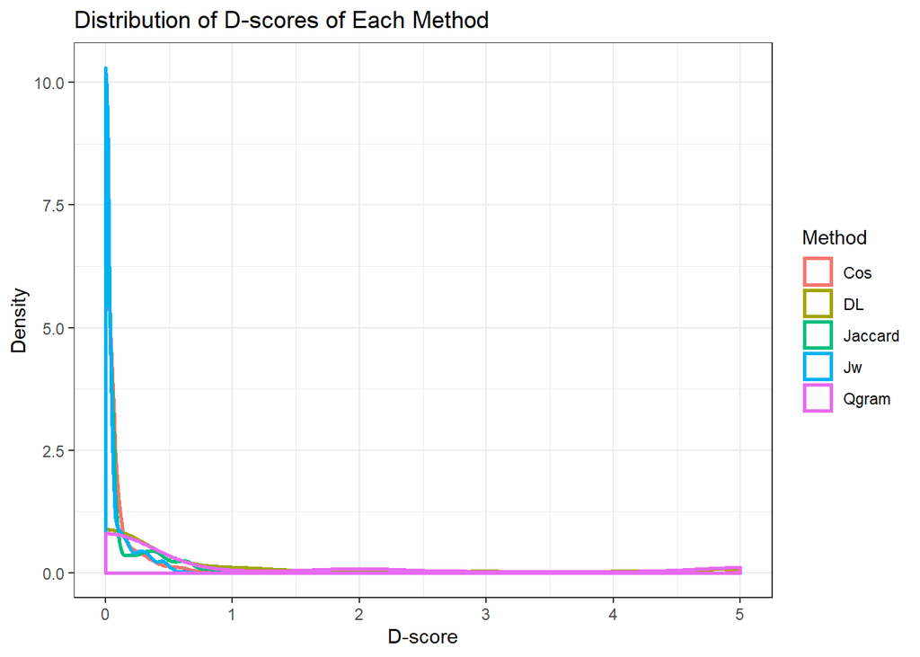

# 5. Further tuning of dscore

Using dscore relative to each ED as the `max_dist` for `stringdist_join()`.

First, get the mean and sd dscore for each ED.

Run again, this time max_dist is dependent on mean and sd dscore of ED, output is `match_dict_imp`.

## 5.1 EDA of results

How consistent are the matches?

| No. of Perfect Matches | No. of Records | % |
| --- | --- | --- |
| 0 | 195 | 23.9 |
| 4 | 5 | 0.6 |
| 5 | 615 | 75.5 |

| No. of Unique Matches Given by Algorithms | No. of Records | % |
| --- | --- | --- |
| 1 | 725 | 89.0 |
| 2 | 67 | 8.2 |
| 3 | 16 | 2.0 |
| 4 | 7 | 0.9 |

The results are similar to before. This is because the original string distance join used a very high threshold (5), hence false negatives are unlikely to occur and the results will still hold.

### Result 2: Identical matches, different from cleaned string

Exploring cases where all string algorithms returned the same result different to cleaned string:

| ED | raw | clean | match_dl | dscore_dl | match_qgram | dscore_qgram | match_cos | dscore_cos | match_jac | dscore_jac | match_jw | dscore_jw |
| --- | --- | --- | --- | --- | --- | --- | --- | --- | --- | --- | --- | --- |
| 0001 | DOUGHERTY ST | DOUGHERTY | DOUGHTY | 2 | DOUGHTY | 2 | DOUGHTY | 0.1180829 | DOUGHTY | 0.2222222 | DOUGHTY | 0.0740741 |
| 0001 | HECKS ST | HECKS | HICKS | 1 | HICKS | 2 | HICKS | 0.2000000 | HICKS | 0.3333333 | HICKS | 0.1333333 |
| 0001 | HICK ST | HICK | HICKS | 1 | HICKS | 1 | HICKS | 0.1055728 | HICKS | 0.2000000 | HICKS | 0.0666667 |
| 0001 | MIDDAUGH ST | MIDDAUGH | MIDDAGH | 1 | MIDDAGH | 1 | MIDDAGH | 0.0513167 | MIDDAGH | 0.1428571 | MIDDAGH | 0.0416667 |
| 0001 | MIDDOGH ST | MIDDOGH | MIDDAGH | 1 | MIDDAGH | 2 | MIDDAGH | 0.1111111 | MIDDAGH | 0.2857143 | MIDDAGH | 0.0952381 |
| 0001 | ORELLOW ST | ORELLOW | WILLOW | 3 | WILLOW | 5 | WILLOW | 0.2372299 | WILLOW | 0.5000000 | WILLOW | 0.2539683 |
| 0001 | POLAR ST | POLAR | POPLAR | 1 | POPLAR | 1 | POPLAR | 0.0513167 | POPLAR | 0.0000000 | POPLAR | 0.0555556 |
| 0001 | TALTON STREET | TALTON | FULTON | 2 | FULTON | 4 | FULTON | 0.2783122 | FULTON | 0.4285714 | FULTON | 0.2222222 |
| 0001 | TULTON ST | TULTON | FULTON | 1 | FULTON | 2 | FULTON | 0.1339746 | FULTON | 0.1666667 | FULTON | 0.1111111 |
| 0001 | WELLOW ST | WELLOW | WILLOW | 1 | WILLOW | 2 | WILLOW | 0.1000000 | WILLOW | 0.4000000 | WILLOW | 0.1111111 |
| 0002 | CRAM BERRY ST | CRAM BERRY | CRANBERRY | 2 | CRANBERRY | 3 | CRANBERRY | 0.0963039 | CRANBERRY | 0.3333333 | CRANBERRY | 0.1037037 |
| 0002 | CRAMBERRY ST | CRAMBERRY | CRANBERRY | 1 | CRANBERRY | 2 | CRANBERRY | 0.0666667 | CRANBERRY | 0.2500000 | CRANBERRY | 0.0740741 |
| 0002 | CRAMBERRY STREET | CRAMBERRY | CRANBERRY | 1 | CRANBERRY | 2 | CRANBERRY | 0.0666667 | CRANBERRY | 0.2500000 | CRANBERRY | 0.0740741 |
| 0002 | WILLIAM ST | WILLIAM | WILLOW | 3 | WILLOW | 5 | WILLOW | 0.2372299 | WILLOW | 0.5000000 | WILLOW | 0.2539683 |
| 0003 | CANBERRY | CANBERRY | CRANBERRY | 1 | CRANBERRY | 1 | CRANBERRY | 0.0202041 | CRANBERRY | 0.0000000 | CRANBERRY | 0.0370370 |
| 0003 | WILLIOW STREET | WILLIOW | WILLOW | 1 | WILLOW | 1 | WILLOW | 0.0352362 | WILLOW | 0.0000000 | WILLOW | 0.0476190 |
| 0004 | CLERK ST | CLERK | CLARK | 1 | CLARK | 2 | CLARK | 0.2000000 | CLARK | 0.3333333 | CLARK | 0.1333333 |
| 0004 | CLERK STREET | CLERK | CLARK | 1 | CLARK | 2 | CLARK | 0.2000000 | CLARK | 0.3333333 | CLARK | 0.1333333 |
| 0004 | COLLAGE PLACE | COLLAGE PLACE | COLLEGE PLACE | 1 | COLLEGE PLACE | 2 | COLLEGE PLACE | 0.0377496 | COLLEGE PLACE | 0.0000000 | COLLEGE PLACE | 0.0790598 |
| 0004 | COLUMBIA HIGHTS | COLUMBIA HIGHTS | COLUMBIA HEIGHTS | 1 | COLUMBIA HEIGHTS | 1 | COLUMBIA HEIGHTS | 0.0253206 | COLUMBIA HEIGHTS | 0.0714286 | COLUMBIA HEIGHTS | 0.0208333 |
| 0004 | FAIRMAN ST | FAIRMAN | FURMAN | 2 | FURMAN | 3 | FURMAN | 0.1835034 | FURMAN | 0.2857143 | FURMAN | 0.1507937 |
| 0004 | HICKE STREET | HICKE | HICKS | 1 | HICKS | 2 | HICKS | 0.2000000 | HICKS | 0.3333333 | HICKS | 0.1333333 |
| 0004 | PIENEPORT STREET | PIENEPORT | PIERREPONT | 3 | PIERREPONT | 1 | PIERREPONT | 0.0292747 | PIERREPONT | 0.0000000 | PIERREPONT | 0.1870370 |
| 0005 | FUTON ST | FUTON | FULTON | 1 | FULTON | 1 | FULTON | 0.0871291 | FULTON | 0.1666667 | FULTON | 0.0555556 |
| 0005 | MONSOR PLACE | MONSOR PLACE | MONROE PLACE | 2 | MONROE PLACE | 2 | MONROE PLACE | 0.0645857 | MONROE PLACE | 0.0909091 | MONROE PLACE | 0.0858586 |
| 0005 | PIERRPONT STREET | PIERRPONT | PIERREPONT | 1 | PIERREPONT | 1 | PIERREPONT | 0.0292747 | PIERREPONT | 0.0000000 | PIERREPONT | 0.0333333 |
| 0006 | MONTAGNE TERACE | MONTAGNE TERACE | MONTAGUE TERRACE | 2 | MONTAGUE TERRACE | 3 | MONTAGUE TERRACE | 0.0543891 | MONTAGUE TERRACE | 0.0909091 | MONTAGUE TERRACE | 0.0638889 |
| 0006 | MONTAGUE PERRACE | MONTAGUE PERRACE | MONTAGUE TERRACE | 1 | MONTAGUE TERRACE | 2 | MONTAGUE TERRACE | 0.0363759 | MONTAGUE TERRACE | 0.0833333 | MONTAGUE TERRACE | 0.0416667 |
| 0007 | HEARY STREET | HEARY | HENRY | 1 | HENRY | 2 | HENRY | 0.2000000 | HENRY | 0.3333333 | HENRY | 0.1333333 |
| 0007 | HUNT ALLEY | HUNT ALLEY | HUNTS ALLEY | 1 | HUNTS ALLEY | 1 | HUNTS ALLEY | 0.0392311 | HUNTS ALLEY | 0.1000000 | HUNTS ALLEY | 0.0303030 |

[output cut: 57 more lines]

Similarly, the string distance algorithms seem to be giving the correct match here.

Cases where string distance algorithms return different matches are shown here:

| ED | raw | clean | match_dl | dscore_dl | match_qgram | dscore_qgram | match_cos | dscore_cos | match_jac | dscore_jac | match_jw | dscore_jw |
| --- | --- | --- | --- | --- | --- | --- | --- | --- | --- | --- | --- | --- |
| 0001 | ?? STREET | ?? | VINE | 4 | VINE | 6 | 0 | 0.0000000 | 0 | 0.0000000 | 0 | 0.0000000 |
| 0001 | BECKA ST | BECKA | HICKS | 3 | HICKS | 6 | ELIZABETH PLACE | 0.3739010 | MCKENNEY | 0.6250000 | HICKS | 0.4000000 |
| 0001 | CLEGS OLD ST | CLEGS OLD | 0 | 0 | 0 | 0 | OLD FULTON | 0.3571757 | COLUMBIA HEIGHTS | 0.5333333 | EAST RIVER | 0.4555556 |
| 0001 | COLUMBIA HOTEL | COLUMBIA | 0 | 0 | 0 | 0 | COLUMBIA HEIGHTS | 0.2884875 | COLUMBIA HEIGHTS | 0.4285714 | COLUMBIA HEIGHTS | 0.1666667 |
| 0001 | ELIZABETH ST | ELIZABETH | 0 | 0 | ELIZABETH PLACE | 6 | ELIZABETH PLACE | 0.0954660 | ELIZABETH PLACE | 0.2727273 | ELIZABETH PLACE | 0.1333333 |
| 0001 | FAIRACRE ST | FAIRACRE | 0 | 0 | 0 | 0 | EAST RIVER | 0.3056349 | EAST RIVER | 0.6000000 | POPLAR PLACE | 0.3194444 |
| 0001 | HICKS ST 19 | HICKS ST NINETEENTH | 0 | 0 | 0 | 0 | COLUMBIA HEIGHTS | 0.3666667 | HICKS | 0.4444444 | HICKS | 0.2456140 |
| 0001 | HOLGER LITTES | HOLGER LITTES | 0 | 0 | 0 | 0 | COLUMBIA HEIGHTS | 0.2818152 | COLUMBIA HEIGHTS | 0.4000000 | EVERITT | 0.3003663 |
| 0001 | MCHENNING ST | MCHENNING | MCKENNEY | 4 | MCKENNY | 6 | MCKENNY | 0.2254033 | MCKENNEY | 0.5555556 | MCKENNY | 0.2433862 |
| 0001 | MCKENNA ST | MCKENNA | MCKENNY | 1 | MCKENNY | 2 | MCKENNY | 0.1111111 | MCKENNEY | 0.2857143 | MCKENNY | 0.0952381 |
| 0001 | MCKENNA STREET | MCKENNA | MCKENNY | 1 | MCKENNY | 2 | MCKENNY | 0.1111111 | MCKENNEY | 0.2857143 | MCKENNY | 0.0952381 |
| 0001 | NEW ASSEMBLY DISTRICT 2 | NEW ASSEMBLY DISTRICT 2 | 0 | 0 | 0 | 0 | EAST RIVER | 0.2904337 | COLUMBIA HEIGHTS | 0.5000000 | EVERITT | 0.4182195 |
| 0001 | PROFECTON ROAD | PROFECTON ROAD | 0 | 0 | 0 | 0 | POPLAR | 0.3969773 | POPLAR PLACE | 0.4166667 | FULTON | 0.4742063 |
| 0002 | INSKID | INSKID | 0 | 0 | HICKS | 5 | 0 | 0.0000000 | 0 | 0.0000000 | 0 | 0.0000000 |
| 0003 | CRANBERRY STRET | CRANBERRY STRET | 0 | 0 | 0 | 0 | CRANBERRY | 0.1188961 | CRANBERRY | 0.3000000 | CRANBERRY | 0.1333333 |
| 0003 | MANGE STREET | MANGE | ORANGE | 2 | ORANGE | 3 | 0 | 0.0000000 | 0 | 0.0000000 | ORANGE | 0.1777778 |
| 0005 | AULTON STREET | AULTON | FULTON | 1 | FULTON | 2 | 0 | 0.0000000 | 0 | 0.0000000 | FULTON | 0.1111111 |
| 0005 | CLERK ST | CLERK | CLARK | 1 | CLARK | 2 | 0 | 0.0000000 | 0 | 0.0000000 | CLARK | 0.1333333 |
| 0005 | PINEPORT ST | PINEPORT | 0 | 0 | PIERREPONT | 2 | PIERREPONT | 0.0513167 | PIERREPONT | 0.0000000 | 0 | 0.0000000 |
| 0007 | CLISTEN STREET | CLISTEN | CLINTON | 2 | 0 | 0 | 0 | 0.0000000 | 0 | 0.0000000 | 0 | 0.0000000 |
| 0007 | GRACE COUNT ALLEY | GRACE COUNT ALLEY | GRACE COURT ALLEY | 1 | GRACE COURT ALLEY | 2 | GRACE COURT ALLEY | 0.0350987 | GRACE COURT ALLEY | 0.0833333 | GRACE COURT ALLEY | 0.0392157 |
| 0007 | GRACE COURT ALLEYS | GRACE COURT ALLEYS | GRACE COURT ALLEY | 1 | GRACE COURT ALLEY | 1 | GRACE COURT ALLEY | 0.0168079 | GRACE COURT ALLEY | 0.0833333 | GRACE COURT ALLEY | 0.0185185 |
| 0007 | JEROLEMAN STREET | JEROLEMAN | 0 | 0 | JORALEMON | 2 | JORALEMON | 0.0909091 | JORALEMON | 0.0000000 | 0 | 0.0000000 |
| 0009 | JOROLEMON ST | JOROLEMON | 0 | 0 | 0 | 0 | JORALEMON | 0.0658013 | JORALEMON | 0.1250000 | JORALEMON | 0.0740741 |
| 0011 | SYDNEY PLACE | SYDNEY PLACE | SIDNEY PLACE | 1 | SIDNEY PLACE | 2 | 0 | 0.0000000 | SIDNEY PLACE | 0.0909091 | 0 | 0.0000000 |
| 0012 | PERROTT PREMPONT STREET | PERROTT PREMPONT | 0 | 0 | 0 | 0 | PIERREPONT | 0.1077822 | 0 | 0.0000000 | 0 | 0.0000000 |
| 0014 | #143 COURT ST | #143 COURT | COURT | 5 | COURT | 5 | COURT | 0.2928932 | COURT | 0.5000000 | BOERUM PLACE | 0.5277778 |
| 0014 | CADYER ST | CADYER | BERGEN | 5 | DEAN | 4 | DEAN | 0.3876276 | DEAN | 0.5714286 | COURT | 0.4222222 |
| 0014 | CHOUPIC ST | CHOUPIC | COURT | 4 | COURT | 6 | PACIFIC | 0.2964735 | COURT | 0.6250000 | COURT | 0.3238095 |
| 0015 | HARRIS COURT | HARRIS COURT | 0 | 0 | 0 | 0 | HOWARD COURT | 0.1750421 | HOWARD COURT | 0.3333333 | HOWARD COURT | 0.1666667 |

[output cut: 60 more lines]

For these cases, it seems like the modal match (i.e. most common match) is a good representative of the true match. This hypothesis is tested and a few issues are described.

Code to extract the modal match:  
*Note: this required creating a `modal()` function to extract the mode (code hidden). If there are more than two modes, the result returns “mode1+mode2”*

How many records have single (i.e. at least 3 algorithms giving same result), non-NA modes?

```
## [1] 757
```

This represents 92.9% of the sample. They are again shown here:

| ED | raw | clean | mode |
| --- | --- | --- | --- |
| 0001 | BECKA ST | BECKA | HICKS |
| 0001 | COLUMBIA HOTEL | COLUMBIA | COLUMBIA HEIGHTS |
| 0001 | COLUMBIA HTS | COLUMBIA HEIGHTS | COLUMBIA HEIGHTS |
| 0001 | DOUGHERTY ST | DOUGHERTY | DOUGHTY |
| 0001 | ELIZABETH ST | ELIZABETH | ELIZABETH PLACE |
| 0001 | FULTON ST | FULTON | FULTON |
| 0001 | FURMAN ST | FURMAN | FURMAN |
| 0001 | FURMAN STREET | FURMAN | FURMAN |
| 0001 | HECKS ST | HECKS | HICKS |
| 0001 | HENRY STREET | HENRY | HENRY |
| 0001 | HICK ST | HICK | HICKS |
| 0001 | HICKS ST | HICKS | HICKS |
| 0001 | HICKS STREET | HICKS | HICKS |
| 0001 | MCHENNING ST | MCHENNING | MCKENNY |
| 0001 | MCKENNA ST | MCKENNA | MCKENNY |
| 0001 | MCKENNA STREET | MCKENNA | MCKENNY |
| 0001 | MIDDAGH | MIDDAGH | MIDDAGH |
| 0001 | MIDDAGH ST | MIDDAGH | MIDDAGH |
| 0001 | MIDDAUGH ST | MIDDAUGH | MIDDAGH |
| 0001 | MIDDOGH ST | MIDDOGH | MIDDAGH |
| 0001 | ORELLOW ST | ORELLOW | WILLOW |
| 0001 | POLAR ST | POLAR | POPLAR |
| 0001 | POPLAR | POPLAR | POPLAR |
| 0001 | POPLAR ST | POPLAR | POPLAR |
| 0001 | POPLAR STREET | POPLAR | POPLAR |
| 0001 | TALTON STREET | TALTON | FULTON |
| 0001 | TULTON ST | TULTON | FULTON |
| 0001 | VINE | VINE | VINE |
| 0001 | VINE ST | VINE | VINE |
| 0001 | WELLOW ST | WELLOW | WILLOW |

[output cut: 727 more lines]

#### Issue 1: Situations where the less common match is identical to clean

In the MN sample, it was found that there are a few records (10, 1.6%) were 2 string algorithms return a perfect match. This is important to examine because if only 2 string algorithms gave a true, correct match, the modal match would not identify this. However, none exist for Brooklyn.

#### Issue 2: Multiple modes

There may be situations there are multiple modes.

| ED | raw | clean | mode |
| --- | --- | --- | --- |
| 0001 | FAIRACRE ST | FAIRACRE | 0+EAST RIVER |
| 0001 | HICKS ST 19 | HICKS ST NINETEENTH | 0+HICKS |
| 0001 | HOLGER LITTES | HOLGER LITTES | 0+COLUMBIA HEIGHTS |
| 0021 | BOHAN ST | BOHAN | HOYT+RED HOOK LANE |
| 0032 | MILL AVE | MILL AVENUE | 0+ATLANTIC AVENUE |
| 0036 | HOYT | HOYT | HIGH+JAY |
| 0118 | BOAT ALSTA COUNTY FOOT OF 223 ST | BOAT ALSTA COUNTY FOOT OF 223 | 0+2 AVENUE |
| 0118 | LALLA BALLEN SUMMING BOTLE FOOT | LALLA BALLEN SUMMING BOTLE FOOT | 0+2 AVENUE |
| 0126 | SHIRD AVE | SHIRD AVENUE | 2 AVENUE+EAST RIVER |
| 0129 | SHIRD AVENUE | SHIRD AVENUE | 0+EAST RIVER |

There are 10 such rows, i.e. 1.2% of the sample.

To clean these, there are a few options:  
1. Potentially use the mode that has a lower dscore–although this is problematic as the different algorithms may have different dscore ranges, hence it is hard to compare.  
2. Leave blank and fill using fill down. This is recommended as it seems that none of the matches are truly similar.  
3. Manual Cleaning.

#### Issue 3: There are matches, but the mode is NA

| raw | clean | match_dl | match_qgram | match_cos | match_jac | match_jw |
| --- | --- | --- | --- | --- | --- | --- |
| ?? STREET | ?? | VINE | VINE | NA | NA | NA |
| CLEGS OLD ST | CLEGS OLD | NA | NA | OLD FULTON | COLUMBIA HEIGHTS | EAST RIVER |
| NEW ASSEMBLY DISTRICT 2 | NEW ASSEMBLY DISTRICT 2 | NA | NA | EAST RIVER | COLUMBIA HEIGHTS | EVERITT |
| PROFECTON ROAD | PROFECTON ROAD | NA | NA | POPLAR | POPLAR PLACE | FULTON |
| INSKID | INSKID | NA | HICKS | NA | NA | NA |
| CLISTEN STREET | CLISTEN | CLINTON | NA | NA | NA | NA |
| PERROTT PREMPONT STREET | PERROTT PREMPONT | NA | NA | PIERREPONT | NA | NA |
| SULLEN ST | SULLEN | FULTON | NA | NA | NA | NA |
| TORLINE ST | TORLINE | NA | FRONT | NA | NA | NA |
| HUGH ST | HUGH | HOYT | NA | NA | NA | NA |
| LIVINGSTON STREET (EVEN) | EVEN | NEVINS | NA | NEVINS AVENUE | NA | NA |
| LIVINGSTON STREET (ODD) | ODD | BOND | BOND | NA | NA | NA |
| STATES STREET | STATES | NA | NA | NA | STATE | NA |
| BOERUM PL | BOERUM PLACE | NA | NA | SCHERMERHORN | ATLANTIC AVENUE | NA |
| HUGH ST | HUGH | HOYT | NA | NA | NA | NA |
| STREET |  | NULL | NULL | NA | NA | NA |
| BRIDGE PLAZA | BRIDGE PLAZA | NA | NA | NA | BRIDGE | BRIDGE |
| JAY ST JOHNSON ST | JAY ST JOHNSON | NA | NA | JOHNSON | JOHNSON | NA |
| PURFLEET AVE | PURFLEET AVENUE | NA | NA | PROSPECT AVENUE | PROSPECT AVENUE | NA |
| THIRD | 3 | 20 | 20 | NA | NA | NA |
| THIRD (3RD) AVENUE | 3 | NA | 20 | NA | NA | NA |
| POST OF 22 ST SAUAL BOST | POST OF 22 ST SAUAL BOST | NA | NA | EAST RIVER | 2 AVENUE | 22 |
| TOOT OF 22ND ST | TOOT OF 22 | NA | NA | 22 | 2 AVENUE | NA |
| 24TH ST DOCK | 24 ST DOCK | NA | NA | NA | 24 | 24 |
| SEVENTY-NINTH | 79 | 29 | 29 | NA | NA | NA |

There are 25 such records (3.1%). Again, there are instances where one of the non-mode matches seems correct, and others where the mode is correct. Nonetheless, fill down cleaning is recommended instead, especially due to the small size of this issue.

### Result 4: No matches at all

Lastly, using this method returns records (23 records, 2.8%) that have no matches at all. These are shown below:

| ED | raw | clean | match_dl | dscore_dl | match_qgram | dscore_qgram | match_cos | dscore_cos | match_jac | dscore_jac | match_jw | dscore_jw | mode |
| --- | --- | --- | --- | --- | --- | --- | --- | --- | --- | --- | --- | --- | --- |
| 0002 | NEW AD 2 | NEW AD 2 | NA | NA | NA | NA | NA | NA | NA | NA | NA | NA | 0 |
| 0003 | COL HETS | COL HETS | NA | NA | NA | NA | NA | NA | NA | NA | NA | NA | 0 |
| 0004 | S HENRY ST & CLAERN AT ROAD | SOUTH HENRY ST CLAERN AT ROAD | NA | NA | NA | NA | NA | NA | NA | NA | NA | NA | 0 |
| 0006 | HICK’S STREET | HICK’SOUTH | NA | NA | NA | NA | NA | NA | NA | NA | NA | NA | 0 |
| 0008 | FORAK MON ST | FORAK MON | NA | NA | NA | NA | NA | NA | NA | NA | NA | NA | 0 |
| 0009 | SLATE ST | SLATE | NA | NA | NA | NA | NA | NA | NA | NA | NA | NA | 0 |
| 0011 | GARDEN PL HENRY STREET | GARDEN PLACE HENRY | NA | NA | NA | NA | NA | NA | NA | NA | NA | NA | 0 |
| 0012 | FIONE RENT STR | FIONE RENT | NA | NA | NA | NA | NA | NA | NA | NA | NA | NA | 0 |
| 0013 | SCHOMERDOSA ST | SCHOMERDOSA | NA | NA | NA | NA | NA | NA | NA | NA | NA | NA | 0 |
| 0016 | MESSICH ST | MESSICH | NA | NA | NA | NA | NA | NA | NA | NA | NA | NA | 0 |
| 0017 | JOHNSON STREET | JOHNSON | NA | NA | NA | NA | NA | NA | NA | NA | NA | NA | 0 |
| 0020 | SAND ROADS | SAND ROADS | NA | NA | NA | NA | NA | NA | NA | NA | NA | NA | 0 |
| 0029 | SECITRIST STREET | SECITRIST | NA | NA | NA | NA | NA | NA | NA | NA | NA | NA | 0 |
| 0033 | RIVAS ST | RIVAS | NA | NA | NA | NA | NA | NA | NA | NA | NA | NA | 0 |
| 0034 | JILLAM STREET | JILLAM | NA | NA | NA | NA | NA | NA | NA | NA | NA | NA | 0 |
| 0037 | LARSON | LARSON | NA | NA | NA | NA | NA | NA | NA | NA | NA | NA | 0 |
| 0038 | STYPKER | STYPKER | NA | NA | NA | NA | NA | NA | NA | NA | NA | NA | 0 |
| 0039 | GEORGTLE ST | GEORGTLE | NA | NA | NA | NA | NA | NA | NA | NA | NA | NA | 0 |
| 0040 | LAAVIUK ST | LAAVIUK | NA | NA | NA | NA | NA | NA | NA | NA | NA | NA | 0 |
| 0120 | SAVE | SAVE | NA | NA | NA | NA | NA | NA | NA | NA | NA | NA | 0 |
| 0122 | GROUT | GROUT | NA | NA | NA | NA | NA | NA | NA | NA | NA | NA | 0 |
| 0127 | 3 AVES | 3 AVES | NA | NA | NA | NA | NA | NA | NA | NA | NA | NA | 0 |
| 0130 | FOURTH (4) AVENUE | 4 | NA | NA | NA | NA | NA | NA | NA | NA | NA | NA | 0 |

# 6. Extracting Best Matches + Fill Down?

Recap of types of result:  
1. Algthms return same match, match = clean. `Match` = match (i.e. mode)  
2. Algthms return same match, match != clean. `Match` = match (i.e. mode) 3. Algthms return diff matches, singular non-NA mode. `Match` = mode(match)  
4. Algthms return diff matches, multiple modes. `Match` = NA  
5. Result 3iii: Algthms return diff matches, mode is NA. `Match` = NA  
6. Algthms return no matches. `Match` = NA

This equates to the following nested conditional for classifying:

```r
if (match_dl == match_cos & match_dl == match_qgram & match_dl == match_jac & match_dl == match_jw) {
    if (clean == match_dl) {1} else if (mode == 0) {6} else {2}
   } else {
    if (str_detect(mode, "\\+")) {4} else if (mode == 0) {5} else {3}
   }
}
```

Code to extract best match:

## 6.1. Fill down?

Proposed Fill down method: 1. Flag NAs  
2. Extract the matched string of 3 rows above and below the records with missing matches, subject to condition that those rows are in the same ED. This forms the pool of potential matches.  
3. Match cleaned string of missing record to the potential matches using jw.

To examine if fill down will work, records with no matches (i.e. type 4, 5, 6), and their above/below 3 records are extracted. For this EDA, the code extracts the above/below 3 regardless of whether the match was in the same ED (for simplicity’s sake).

| ED | raw | best_match |
| --- | --- | --- |
| 0001 | ?? STREET | HICKS |
| 0001 | BECKA ST | HICKS |
| 0001 | CLEGS OLD ST | HICKS |
| 0001 | COLUMBIA HOTEL | COLUMBIA HEIGHTS |
| 0001 | COLUMBIA HTS | COLUMBIA HEIGHTS |
| 0001 | DOUGHERTY ST | DOUGHTY |
| 0001 | ELIZABETH ST | ELIZABETH PLACE |
| 0001 | FAIRACRE ST | FURMAN |
| 0001 | FULTON ST | FULTON |
| 0001 | FURMAN ST | FURMAN |
| 0001 | FURMAN STREET | FURMAN |
| 0001 | HENRY STREET | HENRY |
| 0001 | HICK ST | HICKS |
| 0001 | HICKS ST | HICKS |
| 0001 | HICKS ST 19 | HICKS |
| 0001 | HICKS STREET | HICKS |
| 0001 | HOLGER LITTES | HICKS |
| 0001 | MCHENNING ST | MCKENNY |
| 0001 | MCKENNA ST | MCKENNY |
| 0001 | MCKENNA STREET | MCKENNY |
| 0001 | MIDDAGH ST | MIDDAGH |
| 0001 | MIDDAUGH ST | MIDDAGH |
| 0001 | MIDDOGH ST | MIDDAGH |
| 0001 | NEW ASSEMBLY DISTRICT 2 | WILLOW |
| 0001 | ORELLOW ST | WILLOW |
| 0001 | POLAR ST | POPLAR |
| 0001 | POPLAR | POPLAR |
| 0001 | POPLAR ST | POPLAR |
| 0001 | POPLAR STREET | POPLAR |
| 0001 | PROFECTON ROAD | FULTON |

[output cut: 309 more lines]

# 7. Conclusion

To recap the types of results:

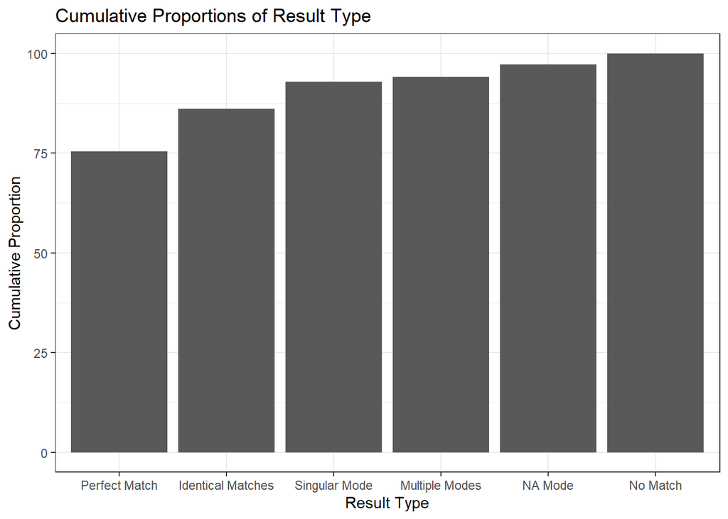

The script worked even better for the Brooklyn sample compared to Manhattan!